# Module 10 Homework

Diana McSpadden

4/22/2021

# Module 10 Homework

## H. Diana McSpadden (hdm5s)

# Question 8

On the USArrests data, calculate PVE in two ways:

## (a) Using the sdev output of the prcomp() function, as was done in

Section 10.2.3.

```r
summary(USArrests)
```

```
##      Murder          Assault         UrbanPop          Rape
##  Min.   : 0.800   Min.   : 45.0   Min.   :32.00   Min.   : 7.30
##  1st Qu.: 4.075   1st Qu.:109.0   1st Qu.:54.50   1st Qu.:15.07
##  Median : 7.250   Median :159.0   Median :66.00   Median :20.10
##  Mean   : 7.788   Mean   :170.8   Mean   :65.54   Mean   :21.23
##  3rd Qu.:11.250   3rd Qu.:249.0   3rd Qu.:77.75   3rd Qu.:26.18
##  Max.   :17.400   Max.   :337.0   Max.   :91.00   Max.   :46.00
```

```r
summary(scale(USArrests))
```

```
##      Murder           Assault           UrbanPop             Rape
##  Min.   :-1.6044   Min.   :-1.5090   Min.   :-2.31714   Min.   :-1.4874
##  1st Qu.:-0.8525   1st Qu.:-0.7411   1st Qu.:-0.76271   1st Qu.:-0.6574
##  Median :-0.1235   Median :-0.1411   Median : 0.03178   Median :-0.1209
##  Mean   : 0.0000   Mean   : 0.0000   Mean   : 0.00000   Mean   : 0.0000
##  3rd Qu.: 0.7949   3rd Qu.: 0.9388   3rd Qu.: 0.84354   3rd Qu.: 0.5277
##  Max.   : 2.2069   Max.   : 1.9948   Max.   : 1.75892   Max.   : 2.6444
```

```r
pr.out = prcomp(USArrests , scale =TRUE)
pr.var = pr.out$sdev^2
pve=pr.var/sum(pr.var)
print("SDEV Calculation of PVE per PC:")
```

```
## [1] "SDEV Calculation of PVE per PC:"
```

```r
pve
```

```
## [1] 0.62006039 0.24744129 0.08914080 0.04335752
```

##(b) By applying Equation 10.8 directly. That is, use the prcomp() function to compute the principal component loadings. Then, use those loadings in Equation 10.8 to obtain the PVE.

```r
head(pr.out$x)
```

```
##                   PC1        PC2         PC3          PC4
## Alabama    -0.9756604  1.1220012 -0.43980366  0.154696581
## Alaska     -1.9305379  1.0624269  2.01950027 -0.434175454
## Arizona    -1.7454429 -0.7384595  0.05423025 -0.826264240
## Arkansas    0.1399989  1.1085423  0.11342217 -0.180973554
## California -2.4986128 -1.5274267  0.59254100 -0.338559240
## Colorado   -1.4993407 -0.9776297  1.08400162  0.001450164
```

```r
pr.out$x[1,1]
```

```
## [1] -0.9756604
```

```r
numerator_pc = 0

numerator_pc = (pr.out$x^2)
#head(numerator_pc)

numerator_pc = apply(numerator_pc, 2, sum)  # apply sum on columns (second arg = 2 == columns)

#numerator_pc
```

```r
squared_sum = 0

squared_sum = (scale(USArrests))^2
#head(squared_sum)
squared_sum = apply(squared_sum, 2, sum) # apply sum on columns (second arg = 2 == columns)
sum_squared_sum = sum(squared_sum)


print("Manually Calculated PVE per PC:")
```

```
## [1] "Manually Calculated PVE per PC:"
```

```r
numerator_pc / sum_squared_sum
```

```
##        PC1        PC2        PC3        PC4
## 0.62006039 0.24744129 0.08914080 0.04335752
```

# Question 9

Consider the USArrests data. We will now perform hierarchical clustering on the states.

## (a) Using hierarchical clustering with complete linkage …

and Euclidean distance, cluster the states.

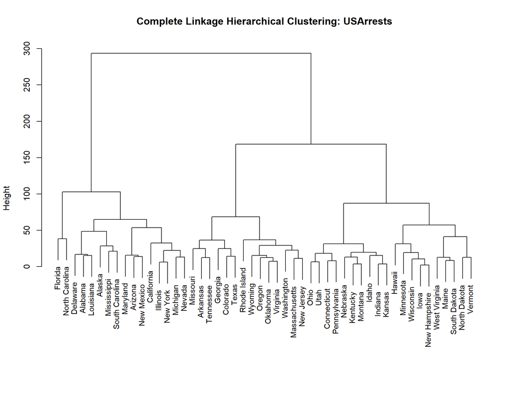

```r
hc_USArrests_complete = hclust(dist(USArrests), method="complete") # complete linkage
plot(hc_USArrests_complete,main="Complete Linkage Hierarchical Clustering: USArrests", xlab="", sub="", cex=.9)
```

## (b) Cut the dendrogram at a height that results …

in three distinct clusters. Which states belong to which clusters?

**Process Q9b:**

```r
library(tidyverse)
usArrests_cut_3 = cutree(hc_USArrests_complete, k = 3)
print("Cluster One:")
```

```
## [1] "Cluster One:"
```

```r
usArrests_cut_3[usArrests_cut_3 == 1]
```

```
##        Alabama         Alaska        Arizona     California       Delaware
##              1              1              1              1              1
##        Florida       Illinois      Louisiana       Maryland       Michigan
##              1              1              1              1              1
##    Mississippi         Nevada     New Mexico       New York North Carolina
##              1              1              1              1              1
## South Carolina
##              1
```

```r
print("Cluster Two:")
```

```
## [1] "Cluster Two:"
```

```r
usArrests_cut_3[usArrests_cut_3 == 2]
```

```
##      Arkansas      Colorado       Georgia Massachusetts      Missouri
##             2             2             2             2             2
##    New Jersey      Oklahoma        Oregon  Rhode Island     Tennessee
##             2             2             2             2             2
##         Texas      Virginia    Washington       Wyoming
##             2             2             2             2
```

```r
print("Cluster Three:")
```

```
## [1] "Cluster Three:"
```

```r
usArrests_cut_3[usArrests_cut_3 == 3]
```

```
##   Connecticut        Hawaii         Idaho       Indiana          Iowa
##             3             3             3             3             3
##        Kansas      Kentucky         Maine     Minnesota       Montana
##             3             3             3             3             3
##      Nebraska New Hampshire  North Dakota          Ohio  Pennsylvania
##             3             3             3             3             3
##  South Dakota          Utah       Vermont West Virginia     Wisconsin
##             3             3             3             3             3
```

## (c) Hierarchically cluster the states using complete linkage…

and Euclidean distance, after scaling the variables to have standard deviation one.

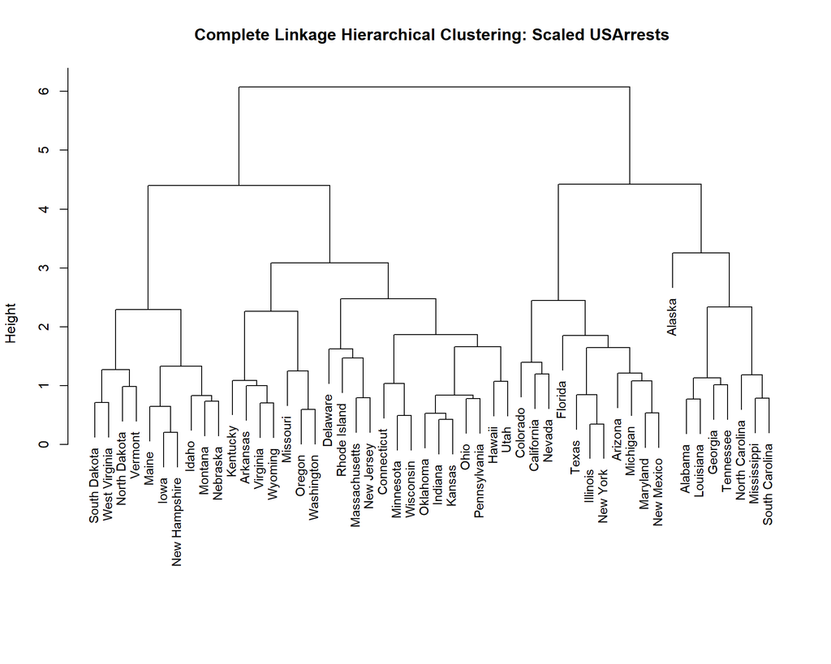

```r
hc_USArrests_scaled_complete = hclust(dist(scale(USArrests)), method="complete") # complete linkage
plot(hc_USArrests_scaled_complete,main="Complete Linkage Hierarchical Clustering: Scaled USArrests", xlab="", sub="", cex=.9)
```

##(d) What effect does scaling the variables have on the hierarchical clustering obtained? In your opinion, should the variables be scaled before the inter-observation dissimilarities are computed?

**Q9d Process:** From the dendrogram it does not appear that there is a cut that produces 3 groups, so I will try for 4 groups because I am curious is the clusters make more sense than the not scaled clusters.

```r
usArrests_cut_4 = cutree(hc_USArrests_scaled_complete, k = 4)
print("Cluster One:")
```

```
## [1] "Cluster One:"
```

```r
usArrests_cut_3[usArrests_cut_4 == 1]
```

```
##        Alabama         Alaska        Georgia      Louisiana    Mississippi
##              1              1              2              1              1
## North Carolina South Carolina      Tennessee
##              1              1              2
```

```r
print("Cluster Two:")
```

```
## [1] "Cluster Two:"
```

```r
usArrests_cut_3[usArrests_cut_4 == 2]
```

```
##    Arizona California   Colorado    Florida   Illinois   Maryland   Michigan
##          1          1          2          1          1          1          1
##     Nevada New Mexico   New York      Texas
##          1          1          1          2
```

```r
print("Cluster Three:")
```

```
## [1] "Cluster Three:"
```

```r
usArrests_cut_3[usArrests_cut_4 == 3]
```

```
##      Arkansas   Connecticut      Delaware        Hawaii       Indiana
##             2             3             1             3             3
##        Kansas      Kentucky Massachusetts     Minnesota      Missouri
##             3             3             2             3             2
##    New Jersey          Ohio      Oklahoma        Oregon  Pennsylvania
##             2             3             2             2             3
##  Rhode Island          Utah      Virginia    Washington     Wisconsin
##             2             3             2             2             3
##       Wyoming
##             2
```

```r
print("Cluster Four:")
```

```
## [1] "Cluster Four:"
```

```r
usArrests_cut_3[usArrests_cut_4 == 4]
```

```
##         Idaho          Iowa         Maine       Montana      Nebraska
##             3             3             3             3             3
## New Hampshire  North Dakota  South Dakota       Vermont West Virginia
##             3             3             3             3             3
```

**Answer:** Scaling is important as murder, rape and assault are in values per 100,000 and UrbanPop is the percent of urban population in the state. The different variances for each of the un-scaled predictors will result in heavier weighing of observations with greater variance. I do not think Assualt should have greater importance than the other predictors, so I recommend scaling.